# Coding Assignment #2

Clayton Jones

2025-08-08

### Scenario 1: Data Collection and Summarization

*Gather data for either the 2023 or 2024 NWSL season. Provide a summary of the dataset including the number of players and a list of the variables contained in the dataset.*

```
##     player              pos               squad                age
##  Length:376         Length:376         Length:376         Min.   :16.00
##  Class :character   Class :character   Class :character   1st Qu.:23.00
##  Mode  :character   Mode  :character   Mode  :character   Median :25.00
##                                                           Mean   :25.96
##                                                           3rd Qu.:29.00
##                                                           Max.   :40.00
##                                                           NA's   :7
##      starts          min                xGp90            xAp90
##  Min.   : 0.00   Length:376         Min.   :0.0000   Min.   :0.0000
##  1st Qu.: 3.00   Class :character   1st Qu.:0.0100   1st Qu.:0.0100
##  Median :10.00   Mode  :character   Median :0.0600   Median :0.0500
##  Mean   :10.65                      Mean   :0.1393   Mean   :0.0859
##  3rd Qu.:18.00                      3rd Qu.:0.2200   3rd Qu.:0.1225
##  Max.   :26.00                      Max.   :1.3800   Max.   :0.7500
##
##     xGxAp90          npxGp90         npxGxAp90
##  Min.   :0.0000   Min.   :0.0000   Min.   :0.0000
##  1st Qu.:0.0500   1st Qu.:0.0100   1st Qu.:0.0500
##  Median :0.1300   Median :0.0600   Median :0.1250
##  Mean   :0.2254   Mean   :0.1335   Mean   :0.2195
##  3rd Qu.:0.3525   3rd Qu.:0.2100   3rd Qu.:0.3500
##  Max.   :1.5100   Max.   :1.3800   Max.   :1.5100
##
```

```
## [1] "There are 376 players included in the dataset. The variables inlcuded are:"
```

```
##  [1] "player"    "pos"       "squad"     "age"       "starts"    "min"
##  [7] "xGp90"     "xAp90"     "xGxAp90"   "npxGp90"   "npxGxAp90"
```

Here is a summary of the NWSL dataset used for this assignment. The data is from the 2024 NWSL season and includes 376 players.

*Gather data for either the 2023 or 2024 EPL season. Provide a summary of the dataset including the number of goalkeepers and a list of the variables contained in the dataset.*

```
##     player             nation          post_shot_xG_per_shot_on_target
##  Length:40          Length:40          Min.   :0.060
##  Class :character   Class :character   1st Qu.:0.260
##  Mode  :character   Mode  :character   Median :0.285
##                                        Mean   :0.280
##                                        3rd Qu.:0.310
##                                        Max.   :0.390
##  launch_completion_percent pass_launch_percent  avg_pass_len
##  Min.   : 0.00             Min.   : 14.10      Min.   :24.00
##  1st Qu.:31.12             1st Qu.: 21.25      1st Qu.:27.77
##  Median :33.70             Median : 34.40      Median :33.15
##  Mean   :33.44             Mean   : 36.81      Mean   :33.49
##  3rd Qu.:39.02             3rd Qu.: 47.05      3rd Qu.:37.33
##  Max.   :50.00             Max.   :100.00      Max.   :53.80
##  gk_launch_percent def_actions_out_pen_area_p90
##  Min.   :  9.70    Min.   :0.0000
##  1st Qu.: 40.85    1st Qu.:0.7375
##  Median : 56.75    Median :1.1200
##  Mean   : 53.69    Mean   :1.3388
##  3rd Qu.: 63.30    3rd Qu.:1.6475
##  Max.   :100.00    Max.   :6.0000
```

```
## [1] "There are 40 players included in the dataset. The variables inlcuded are:"
```

```
## [1] "player"                          "nation"
## [3] "post_shot_xG_per_shot_on_target" "launch_completion_percent"
## [5] "pass_launch_percent"             "avg_pass_len"
## [7] "gk_launch_percent"               "def_actions_out_pen_area_p90"
```

Here is a summary of the EPL dataset used for this assignment. The data is from the 2024 EPL season and includes 40 goalkeepers.

### Scenario 2: Clustering NWSL PLayers

*Recreate Figure 8.3 using the updated dataset. To receive full credit, include the year in the title, provide labels for any scorer that is under 20, or has an xGp90 over 0.5. Include the player’s name and xGp90 value in the label.*

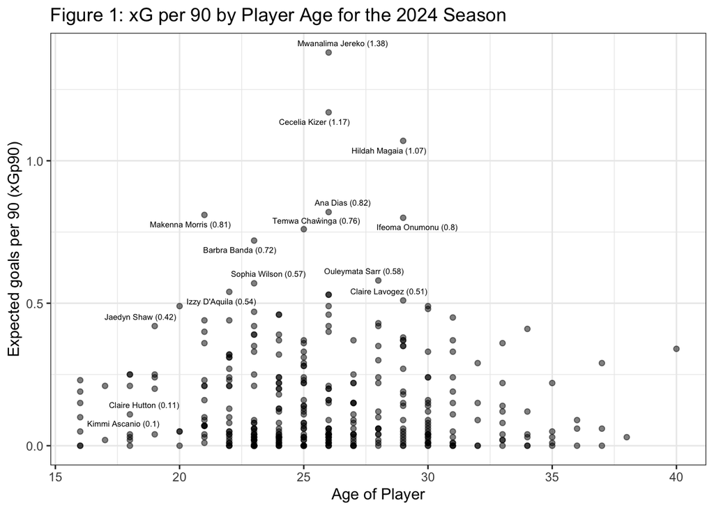

Note: There were so many names clustered in the bottom left corner that some were cut out automatically (15 total) when I initially ran the code. I tried to make the text smaller but it was still cutting a few out so I also tried to increase the max.overlaps, but it made the chart unreadable. I ended up decreasing the font size to 2 (default and reducing to 5 (default 5) to make the chart most readable, which excluded 19 labels. The NWSL must have added a bunch of younger players since 2022, as this was not a problem with the plot in the textbook.

*Recreate Figure 8.10 using the updated dataset. Cluster the athletes using xGp90, xAp90 ensuring that you have appropriately normalized these values. Include the cluster (color) and position (shape) in the plot. In addition, provide a table that summarizes the number of athletes assigned to each cluster and position combination (a total of 9 possibilities).*

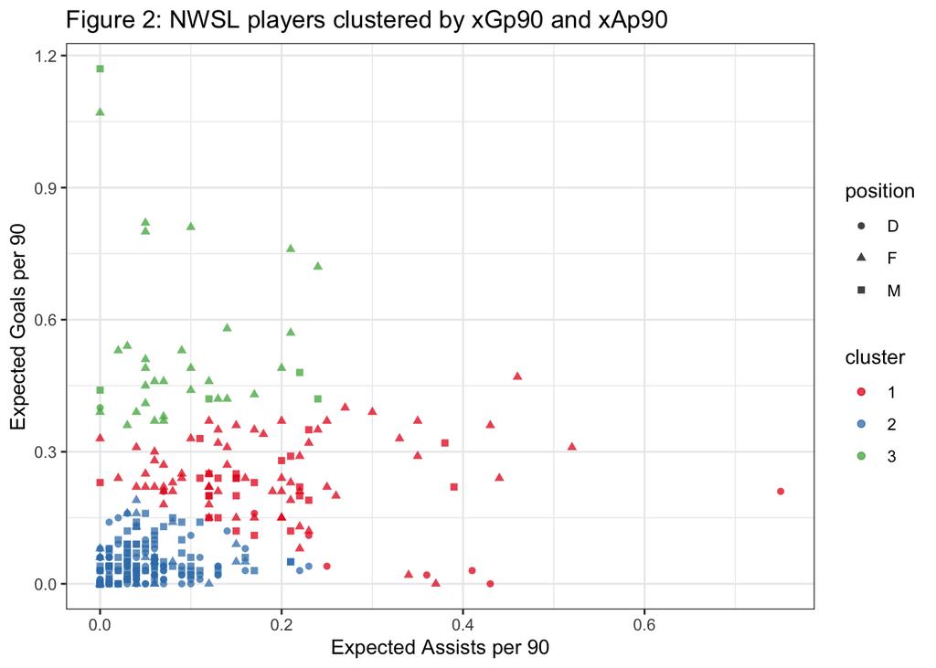

Count of Each Position/Cluster Combination

| Position | Cluster | Count |
| --- | --- | --- |
| D | 1 | 8 |
| D | 2 | 112 |
| D | 3 | 1 |
| F | 1 | 64 |
| F | 2 | 22 |
| F | 3 | 30 |
| M | 1 | 25 |
| M | 2 | 77 |
| M | 3 | 5 |

In the graph above, expected goals and assists are normalized to 90 minutes to account for different players playing different number of minutes. Looking at the Figure 2, cluster 2 is all low expected assists and goals per 90. Cluster 1 has higher expected goals per 90, and it is interesting that all players with expected assists per 90 greater than 0.3 were assigned to cluster 1. Cluster 3 is made up of the players with the highest expected goals per 90. It really seems as though it was mostly clustered by expected goals per 90 and not expected assists per 90.

*Recreate Figure 8.11 using the updated dataset. Cluster the athletes using player, squad, age, starts, xGp90, xAp90, xGxAp90. Next, provide a table that summarizes the number of players assigned to each cluster for k = 5, and k = 4, respectively. Lastly, provide a summary of which clusters (k = 5 and k = 4 previously) overlap, and which cluster (for k = 5) saw a decrease in assignment (for k = 4).*

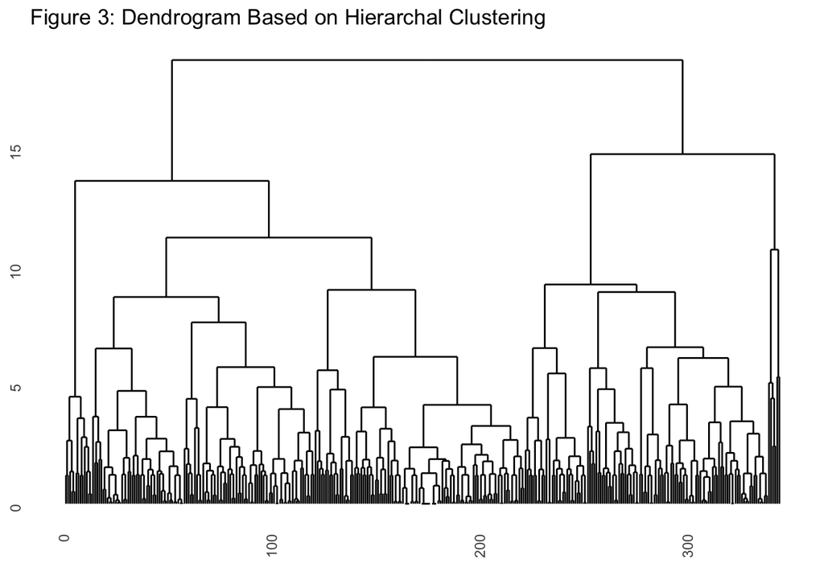

Number of Players Assigned to Each Cluster for k=5 and k=4

| Cluster | Count (k=4) | Count (k=5) |
| --- | --- | --- |
| 1 | 117 | 117 |
| 2 | 208 | 101 |
| 3 | 13 | 107 |
| 4 | 6 | 13 |
| 5 | NA | 6 |

### Scenario 3: Evaluating EPL Goal Keepers

*Recreate the results for k-means clustering for k = 2 and k = 3, similar to Section 8.9 Step 1. Provide a table that summarizes the cluster means for k = 2 and k = 3, and provide a summary of the % of variation explained.*

Cluster Means for k=2 and k=3

|  | Cluster 1 Mean (k=2) | Cluster 2 Mean (k=2) | Cluster 1 Mean (k=3) | Cluster 2 Mean (k=3) | Cluster 3 Mean (k=3) |
| --- | --- | --- | --- | --- | --- |
| Postshot Expected Goals per Shot on Target | 0.2913636 | 0.2661111 | 0.2387500 | 0.2961538 | 0.2863158 |
| Launch Completion Percentage | 34.03636 | 32.71667 | 31.63750 | 35.17692 | 33.01579 |
| Pass Launch Percentage | 24.06818 | 52.37778 | 64.31250 | 19.29231 | 37.21053 |
| Average Pass Length | 28.61818 | 39.44444 | 43.75000 | 26.54615 | 33.92105 |
| Goal Kick Launch Percentage | 42.89091 | 66.88333 | 72.41250 | 34.11538 | 59.19474 |
| Defensive Actions Outside the Penalty Area per 90 Minutes | 1.245455 | 1.452778 | 1.730000 | 1.373077 | 1.150526 |

```
## between_SS / total_SS for k=2: 44.86%
## between_SS / total_SS for k=3: 60.42%
```

As printed above, k=2 had a between_SS/total_SS value of 44.86%, whereas k=3 had a value of 60.42%. These values are the amount of variance in the dataset that can be explained by clustering. The higher value for k=3 means that the points are closer to the cluster means, and there is lower variance in each cluster, this making k=3 the superior choice for clustering this data.

*Create a table that includes cluster membership for k = 2 and k = 3 for each player, similar to Section 8.9 Step 2*

Players, Their Nationalities, and Cluster Assignments for k=2 and k=3

| Player | Nation | Cluster Assignment (k=2) | Cluster Assignment (k=3) |
| --- | --- | --- | --- |
| Aaron Ramsdale | ENG | 1 | 3 |
| David Raya | ESP | 1 | 3 |
| Emiliano Martínez | ARG | 1 | 2 |
| Robin Olsen | SWE | 1 | 2 |
| Ionuț Radu | ROU | 1 | 2 |
| Thomas Strakosha | ALB | 1 | 3 |
| Jason Steele | ENG | 1 | 2 |
| Bart Verbruggen | NED | 1 | 2 |
| Đorđe Petrović | SRB | 1 | 2 |
| Robert Sánchez | ESP | 1 | 2 |
| Bernd Leno | GER | 1 | 3 |
| Alisson | BRA | 1 | 2 |
| Caoimhín Kelleher | IRL | 1 | 2 |
| Ederson | BRA | 1 | 2 |
| Stefan Ortega | GER | 1 | 2 |
| André Onana | CMR | 1 | 3 |
| Martin Dúbravka | SVK | 1 | 2 |
| Nick Pope | ENG | 1 | 3 |
| Odisseas Vlachodimos | GRE | 1 | 3 |
| Guglielmo Vicario | ITA | 1 | 2 |
| Daniel Bentley | ENG | 1 | 3 |
| José Sá | POR | 1 | 3 |
| Neto | BRA | 2 | 3 |
| Mark Travers | IRL | 2 | 1 |
| Mark Flekken | NED | 2 | 3 |
| Arijanet Muric | KVX | 2 | 3 |
| James Trafford | ENG | 2 | 3 |
| Dean Henderson | ENG | 2 | 3 |
| Sam Johnstone | ENG | 2 | 1 |
| Remi Matthews | ENG | 2 | 1 |
| Jordan Pickford | ENG | 2 | 1 |
| Thomas Kaminski | BEL | 2 | 1 |
| James Shea | ENG | 2 | 1 |
| Loris Karius | GER | 2 | 3 |
| Matz Sels | BEL | 2 | 3 |
| Matt Turner | USA | 2 | 3 |
| Wes Foderingham | ENG | 2 | 1 |
| Ivo Grbić | CRO | 2 | 1 |
| Alphonse Areola | FRA | 2 | 3 |
| Łukasz Fabiański | POL | 2 | 3 |

*Recreate the second plot in Section 8.9 Step 4 for both k = 2 and k = 3. To receive full credit, include the number of clusters in the title, and include the error band*

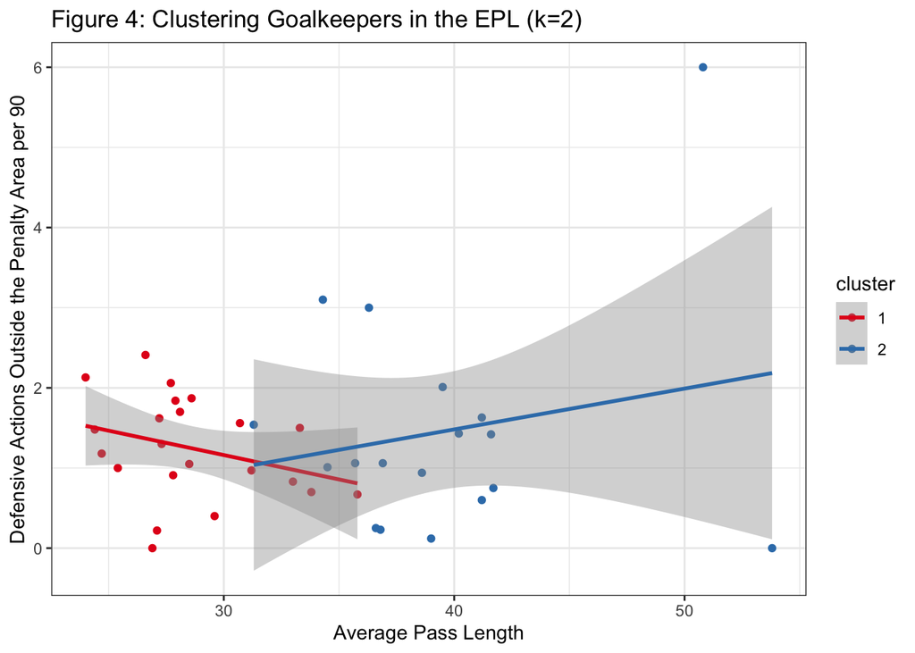

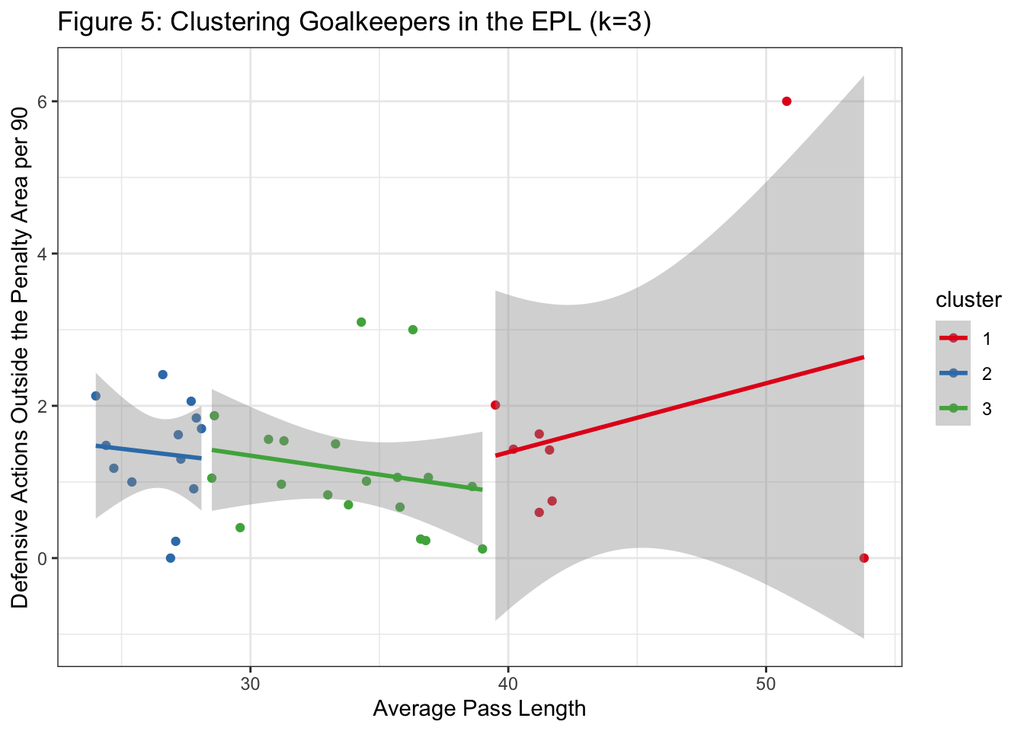